# ISON - Final Assignment

Minwoo (Charlie) Ki, Triya Roy

2023-12-21

# Elite Echo Chambers

## Introduction

The dataset which will be examined for this research is ‘mpn_elite_mex’. It is located in the R package ‘migraph’ and it consists of 35 nodes and 117 ties, representing the social network of members of the Mexican power elite from Knoke’s 1990 work. It is a labelled, undirected network, with each tie representing any formal, informal, or organisational relation between a dyad; common belonging (school, sports, business, political participation), or a common interest (political power).

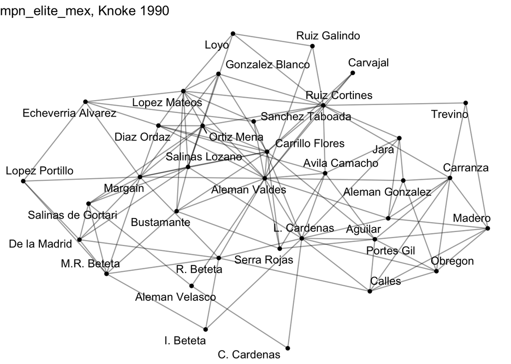

## Research Question

Within this hypothetical scenario, we aim to spread misinformation within this network of Mexican elites, therefore using diffusion simulations, we attempt to discover which node would be the most effective as a mole who will spread misinformation. Simply put, which node is the most effective seed for the diffusion of misinformation?

## Theoretical frameworks and hypotheses

We hypothesise that the optimal seed of diffusion within the Mexican power elite would come from a group displaying significant homophily i.e. nodes with a common attribute share more ties between each other. This is because those who share common interests or backgrounds with a member are more likely to believe them through convergence of beliefs. We will measure the homophily within the Elite using coreness and the military affiliation of the members.

The figures with a high coreness degree represent those members who are more central in the network and who have more connections to other nodes. Hence, we would hypothesise that the members with the highest coreness degree would display homophily compared to the other rest of the nodes i.e. the peripheral nodes.

As a secondary measure of homophily, we can also investigate the members who possess military attributes. We would expect that those members that do possess military attributes would be better seeds of diffusion as there is no trust like the trust between military veterans.

- H1: Peripheral nodes as seed nodes will perform less efficiently than core nodes
- H0: There is no significant difference in efficiency between peripheral nodes and core nodes when used as seed nodes.

In an alternative scenario, in this version of events, core nodes are unavailable as seeds as they are diligent with their source of information, only peripheral nodes will be considered as potential seeds.

- Jacinto B. Trevino is the only node within his peripheral group to possess military affiliation, considering the effects of homophily, choosing Trevino as a node should provide more efficient diffusion

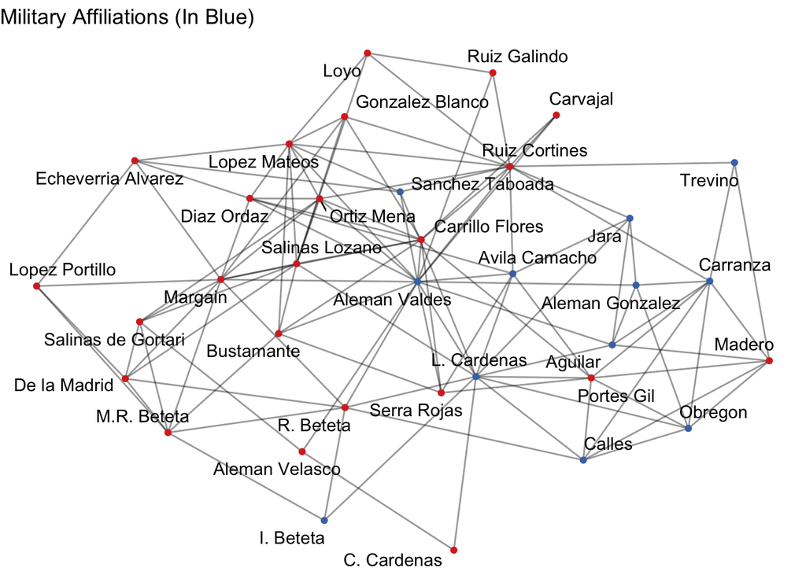

## Key Modelling Decisions

- We created a binary variable “kcoreness” with nodes of highest coreness (5) indicated by kcoreness=1 and the other peripheral nodes (k<5) indicated by kcoreness =0
- We used the ring network in the simulations for easy visualization of diffusion of misinformation within the group
- We used the simulation diffusion model to create hypothetical scenarios of the spread of misinformation through different seed nodes within the elite
- We chose steps=4 because the diffusion for all the 35 hypothetical seed nodes end before or on the fourth step

## Results

Aleman Valdes

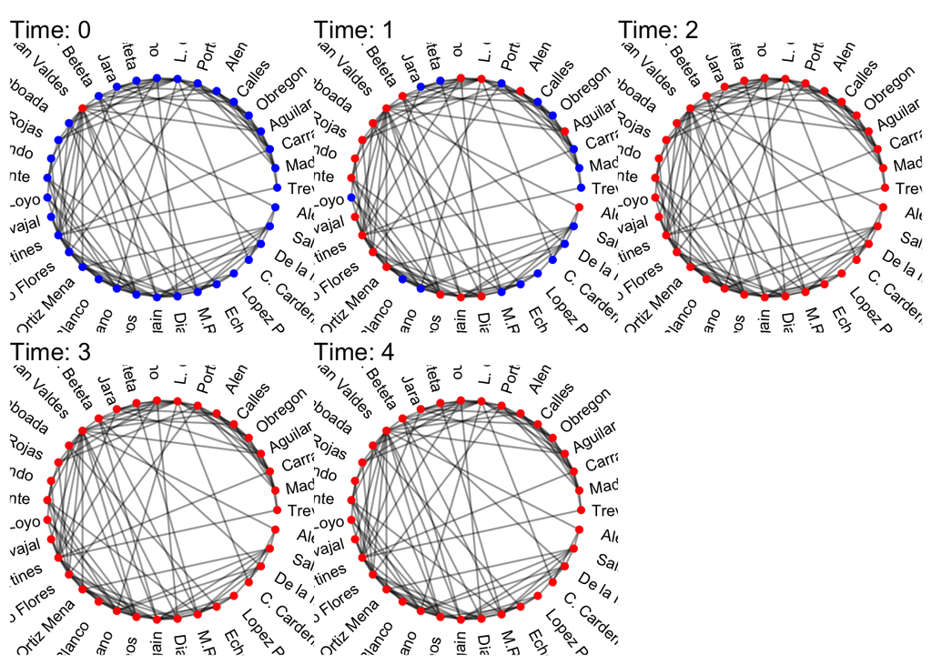

Jacinto B. Trevino

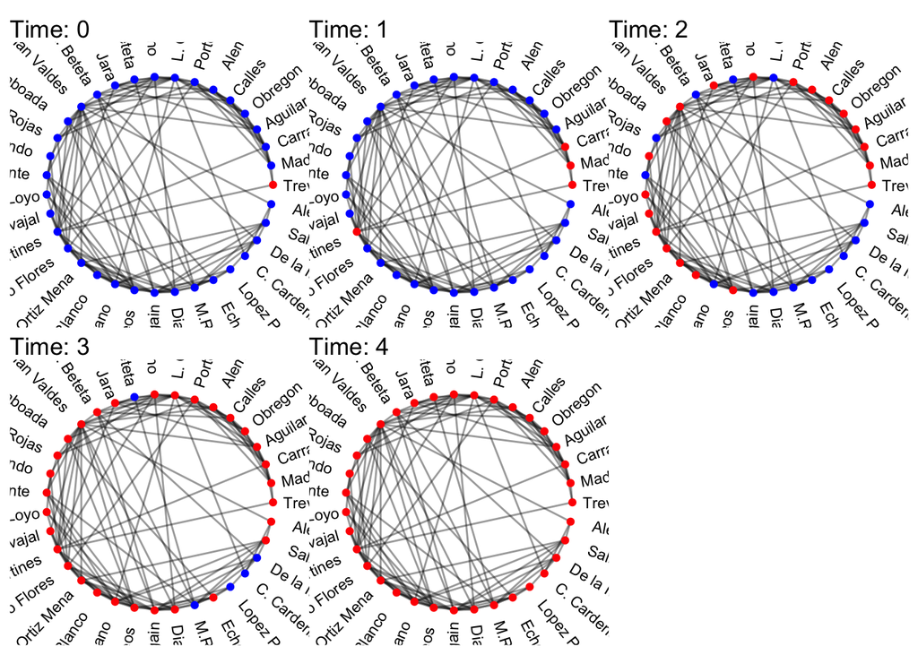

When the homophily of the two variables of “military” and “kcoreness” was calculated, the results showed each respective variable possessing the EI-index of -0.368 and -0.538, implying strong homophily in both variables with the homophily of kcoreness being slightly stronger than that of “military”.

After running diffusion simulations on the 35 hypothetical seed nodes, Aleman Valdes is the most efficient seed i.e. our best point of entry for infiltration in the elite. With the quickest diffusion of 2 steps, he satisfies the conditions we hypothesised for the optimal “mole”. Valdes has both the highest degree of coreness and is affiliated with the military. Although the best-performing seed was a core node, on average, there was no discernible difference in the efficiency of core nodes and peripheral nodes. Therefore, H0 cannot be rejected.

When concerning the peripheral figures and scenario 2, all 4 nodes of Trevino’s peripheral group of kcoreness=3 showed similar results with Trevino being one of the less efficient seed choices, completing the diffusion in 3-4 steps. When considering diffusion effectiveness, military affiliation had an insignificant effect.

## Conclusion

In conclusion, our findings suggest that Valdes emerges as the most effective seed for spreading misinformation among the Mexican power elite. Despite the initial hypothesis favouring core nodes, the study reveals that, on average, there is no significant difference in efficiency between core and peripheral nodes when used as seed points for misinformation diffusion.